# SUS

jquery404

1. Original SUS / repharsed
   - Would use system frequently?
   - System unnecessarily complex?
   - **System easy to use?**
   - Need technical support?
   - Functions well integrated?
   - System inconsistent?
   - Quick to learn system?
   - System cumbersome to use?
   - Confident using system?
   - Steep learning curve?
2. Subscale
   - Q1. The system made it easier to complete my collaborative task.
   - Q2. I found the system’s features were straightforward to understand.
   - Q3. I found the system has steep learning curve.
   - Q4. I found the most of the features confusing.

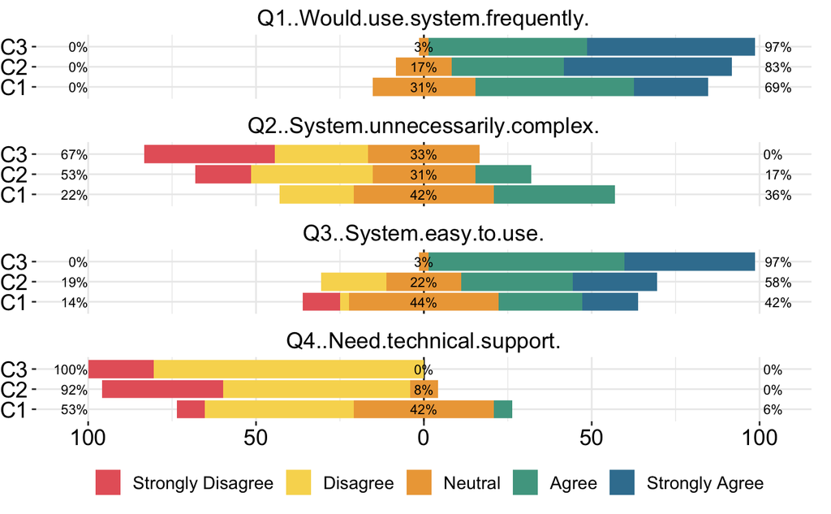

```r
# library
library(ggplot2)
library(ggpubr)
library(dplyr)
library(tidyr)
library(gridExtra)
library(grid)
library(likert)
library(rstatix)
coloring = c("#E76469", "#F8D85E","#EDA645","#D1B0B3","#8C99A6","#ADD299","#4FA490","#3B7F9F")
fontsize = 14
dodge = .75

data=read.csv('csv/sus.csv', sep=",")
data <- as.data.frame(data)
data[5:8] <- lapply(data[5:8], factor, levels=1:5, labels=c("Strongly Disagree", "Disagree", "Neutral","Agree","Strongly Agree"))
likt <- likert(data[,c(5:8)], grouping = data$conditions)

plot(likt, colors = c("#E76469", "#F8D85E","#EDA645","#4FA490","#3B7F9F")) +
  theme_bw() +
  theme(axis.line = element_blank(),
        axis.title.x=element_blank(),
        axis.title.y=element_blank(),
        axis.text.x = element_text(color="black", size=fontsize),
        axis.text.y = element_text(color="black", size=fontsize),
        strip.text = element_text(color="black", size = fontsize),
        strip.background = element_blank(),
        text = element_text(size=fontsize),
        panel.border = element_blank(),
        plot.background = element_blank(),
        plot.margin = unit(c(0.005, .025, 1, 0), "null"),
        legend.title=element_blank(),
        legend.direction="horizontal",
        legend.position = c(.5, -.1),
        legend.justification = c("center", "top"))

ggsave("out/usability.pdf", width = 6.5, height = 4, dpi = 1000)
```